# College: Is It Worth It?

Tyler Moseley

12/9/2019

As winter break approaches, seniors in high school and undergraduate programs all over the country along with their parents are awaiting the results of their undergraduate or graduate admission applications and the results of exams which will determine their eligibility. We will examine longitudinal surveys by the National Survey of College Graduates and the Survey of Doctorate Recipients from a sample of college graduates and doctorate recipients most recently collected (SESTAT 2013). We will attempt to provide insight to some of the critical questions they must answer in order to inform these impending metamorphic decisions: Is college really worth it? What major will result in the highest salary or greatest job satisfaction? Which one is most important?

## The College Landscape

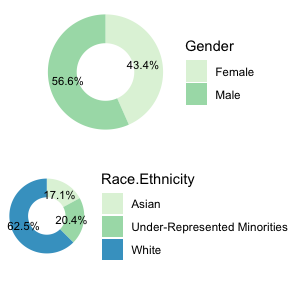

Figure 1.1: Dataset Demographic Make-up

Of the 115,152 respondants in the survey, 43% were female and 57% were male. The majority (63%) reported being white while 17% reported being Asian and 20% reporting their ethnicity as an under-represented minority. Science, engineering and social sciences are consistently the most popular degree paths. Similarly, non-science and engineering fields have a noticably lower retention rate (rate at which undergraduate students stay in their field of study in graduate school).

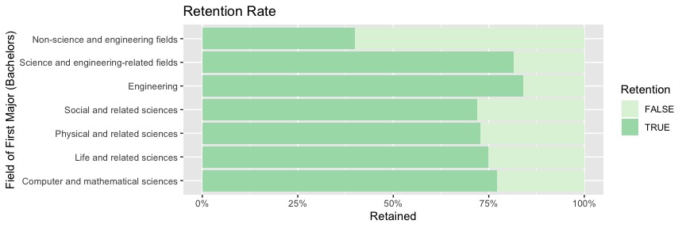

Figure 1.2: Retention Rate by Field of Major

## Maximize Salary?

We examined factors which predict higher salary. Some of the results did match common expections such as an increase in salary as the type of degree gets more advanced. Students who earn a masters instead of a bachelors can expect an increase of around $11,100, continuing for a doctorate can yield around $18,900 over a bachelors and professional degree having an increase of an estimate of $25,800 more than a bachelors. With the exception of engineering, one surprising factor which does not predict salary with a high degree of confidence is field of major for highest degree. Engineering majors can expect to earn approximately $6,250 more than any other major however.

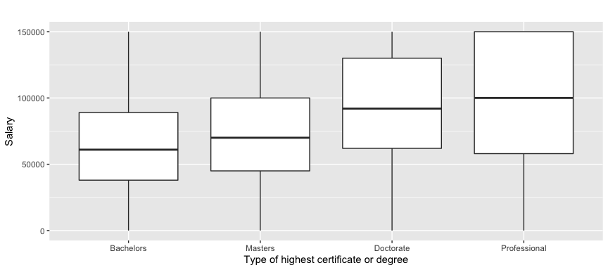

Figure 2.1: Salary vs Highest Degree Obtained

Another interesting finding from this analysis is how salary is predicted by age. It appears that there is an increase in salary associated with age until around 50 years old and then a decline.

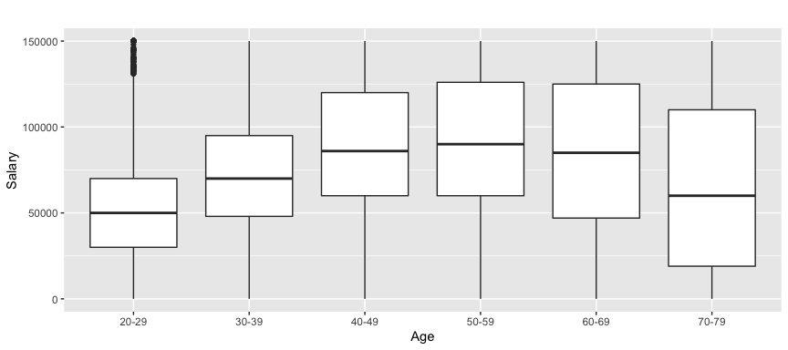

Figure 2.2: Salary vs Age

The best choices to make in order to maximize salary from the model are: Complete Professional Degree, majoring in engineering. Work 40+ hours per week, 40-52 weeks per year in the business/industrial sector. Save for old age/retirement when salary declines or stops.

## Job Satisfaction

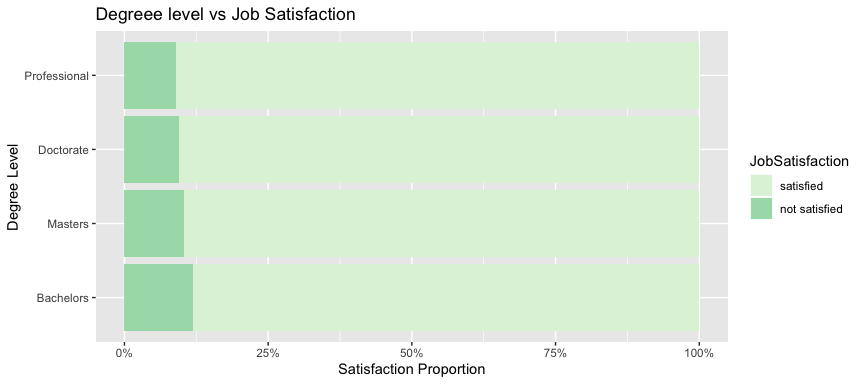

The best choices to make in order to maximize job satisfaction from the model are: Complete Professional Degree, majoring in Computer or Mathematical sciences. Work 40+ hours per week doing “other” work primarily. Maybe consider a job in the life sciences field.

## Mythbusting

There was a Gallup poll (Does Higher Learning = Higher Job Satisfaction?) cited in an article which concluded that, Education level has very little to do with job satisfaction, or satisfaction with income and time flexibility.

In our model, education level was in fact correlated with job satisfaction. We did not take income and time flexibility into consideration however since this was not really a fair comparison. Income and time flexibility is directly related to job satisfaction and universal across all degree levels.

They also claim, Having the opportunity to do what you do best is the one factor that correlates most highly with overall job satisfaction is.

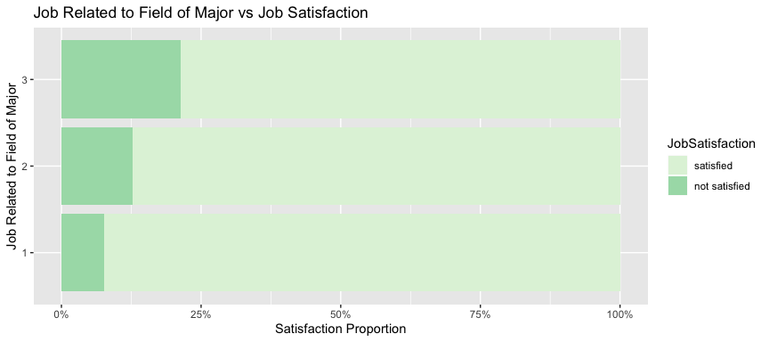

Minnesota Population Center. IPUMS Higher Ed: Version 1.0 [dataset]. Minneapolis, MN: University of Minnesota, 2016. https://doi.org/10.18128/D100.V1.0